# Plant Seedlings Classification

### Objective

Differentiate a weed from a crop seedling. The ability to do so effectively can mean better crop yields and better stewardship of the environment.

### Context

The Aarhus University Signal Processing group, in collaboration with University of Southern Denmark, has recently released a dataset containing images of unique plants belonging to 12 species at several growth stages

### Data Description

Dataset of images of plant seedlings at various stages of grown has been provided. Each image has a filename that is its unique id. The dataset comprises 12 plant species. The goal of the project is to create a classifier capable of determining a plant's species from a photo.

The original files are from Kaggle. The data file names are images.npy and Label.csv. Due to the large volume of data, the images were converted to images.npy file and the labels are also put into the Labels.csv.

Link to the Kaggle project site: https://www.kaggle.com/c/plant-seedlings-classification/data?select=train

Github Link: https://github.com/deepak-padmanabhan/PGP-AIML

### **Import Libraries**

```python
!pip install tensorflow==2.0.0
```

```python
import tensorflow as tf
print(tf.__version__)
```

```
2.0.0
```

```python
!pip install opencv-python
```

```python
import numpy as np
from numpy import array
import pandas as pd

import tensorflow as tf
from tensorflow import keras
from tensorflow.keras.utils import to_categorical
from tensorflow.keras.preprocessing.image import ImageDataGenerator
from tensorflow.keras.models import Sequential, load_model
from tensorflow.keras.layers import Dense, Dropout, Activation, Flatten, Conv2D, MaxPooling2D
from tensorflow.keras.callbacks import ModelCheckpoint, EarlyStopping
import cv2
import matplotlib.pyplot as plt
from matplotlib.pyplot import imshow, show
from sklearn.model_selection import train_test_split
from sklearn.metrics import classification_report
from sklearn.metrics import accuracy_score, confusion_matrix, precision_score, recall_score, f1_score, precision_recall_curve, auc
# Suppress scientific notation in numpy outputs
np.set_printoptions(suppress=True)
```

### Load Dataset

```python
#Load Images
images = np.load('images.npy')
```

```python
#Load labels
labels = pd.read_csv('Labels.csv')
```

```python
#Converting dataframe to numpy arrays
Labels = labels.to_numpy(dtype=str)
```

### Print Shape

```python
print('images shape:', images.shape)
print(images.shape[0], 'image samples')
```

```
images shape: (4750, 128, 128, 3)
4750 image samples
```

```python
print('labels shape:', Labels.shape)
print(Labels.shape[0], 'labels')
print('label of the image at index 0 is:',Labels[0][0])
```

```
labels shape: (4750, 1)
4750 labels
label of the image at index 0 is: Small-flowered Cranesbill
```

```python
#Checking for unique Label values and counts
np.unique(Labels, return_index=True, return_counts=True)
```

```
(array(['Black-grass', 'Charlock', 'Cleavers', 'Common Chickweed',
        'Common wheat', 'Fat Hen', 'Loose Silky-bent', 'Maize',
        'Scentless Mayweed', 'Shepherds Purse',
        'Small-flowered Cranesbill', 'Sugar beet'], dtype='<U25'),
 array([3833, 2034, 2424, 1423, 1202,  496, 4096, 3612, 2711,  971,    0,
        3227], dtype=int64),
 array([263, 390, 287, 611, 221, 475, 654, 221, 516, 231, 496, 385],
       dtype=int64))
```

- The dataset contains 4750 images and labels
- The size of each image is 128x128 pixels
- Each image has 3 color channels
- There are 12 unique plant seedling labels
- Label of the image at index 0 is Small-flowered Cranesbill

```python
labels_dict = {0:'Black-grass',
               1:'Charlock',
               2:'Cleavers',
               3:'Common Chickweed',
               4:'Common wheat',
               5:'Fat Hen',
               6:'Loose Silky-bent',
               7:'Maize',
               8:'Scentless Mayweed',
               9:'Shepherds Purse',
               10:'Small-flowered Cranesbill',
               11:'Sugar beet'
               }
```

### View Images

```
Black-grass
```

[figure not shown]

```
Charlock
```

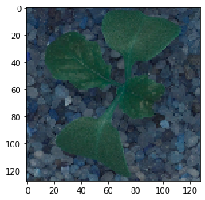

```
Cleavers
```

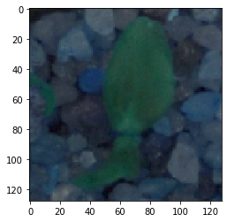

```
Common Chickweed
```

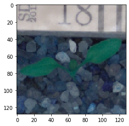

```
Common wheat
```

[figure not shown]

```
Fat Hen
```

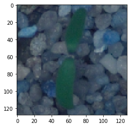

```
Loose Silky-bent
```

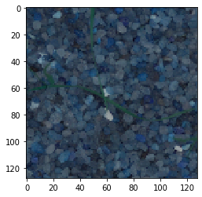

```
Maize
```

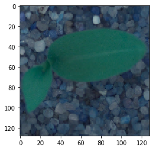

```
Scentless Mayweed
```

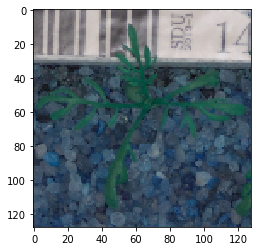

```
Shepherds Purse
```

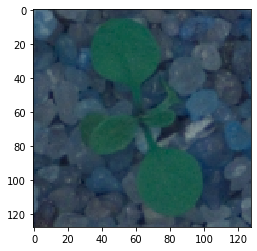

```
Small-flowered Cranesbill
```

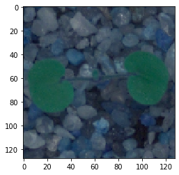

```
Sugar beet
```

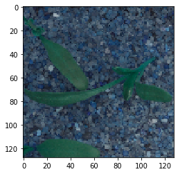

```python
#Displaying all 12 unique labels
indexes = np.array([3833, 2034, 2424, 1423, 1202,496,4096,3612,2711,971,0,3227])
for i in indexes:
    image = images[i]
    label = Labels[i][0]
    print(label)
    plt.imshow(image)
    show()
```

### Data Pre-processing

#### Resizing Image

```python
# Resizing the image to 32 x 32 pixels
resize = np.empty((4750, 32, 32, 3))
for idx, line in enumerate(images):
    resize[idx] = cv2.resize(images[idx], (32, 32))
```

```
Original Image:
```

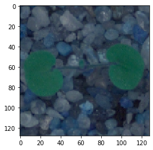

```
 Resized Image:
```

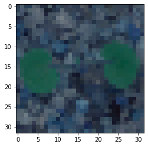

```python
print('Original Image:\n')
plt.imshow(images[0])
show()
print('\n Resized Image: \n')
plt.imshow(resize[0].astype(np.uint8))
show()
```

```python
#rgb_weights = [0.2989, 0.5870, 0.1140]
#gs = np.dot(resize[...,:3], rgb_weights)
#Accuracy was very low with grayscaled image, hence built the model with color images itself
```

```
Resized Image:
```

[figure not shown]

```
 Grayscale Image:
```

[figure not shown]

```python
#print('Resized Image:\n')
#plt.imshow(resize[0].astype(np.uint8))
#show()
#print('\n Grayscale Image: \n')
#plt.imshow(gs[0].astype(np.uint8),cmap='gray')
#show()
```

#### Gaussian Blurring

```python
# Applying Gaussian blurring with 5x5 kernel
blur = np.empty((4750, 32, 32, 3))
for idx, line in enumerate(resize):
    blur[idx] = cv2.GaussianBlur(resize[idx], (5, 5), 0)
```

#### Normalization

```python
# The pixel values are in the range of 0 to 255 for each of the red, green and blue channels.
# Normalizing to the range 0 to 1 by dividing each value by the maximum observation which is 255.

blur = blur.astype('float32')
blur /= 255.0 # Division by 255
```

#### Viewing image after data pre-processing

```
 Output after gaussian blurring:
```

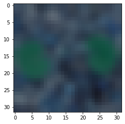

```python
#Visualizing the first image after applying gaussian blurring
print('\n Output after gaussian blurring: \n')
plt.imshow(blur[0])
show()
```

### Make data compatible

#### Convert labels to one-hot-vectors

```python
y = labels
y = pd.get_dummies(y)
y = y.to_numpy()
```

#### Print the label for y[0]

```python
print('Label for first image is:',np.argmax(y[0]))
```

```
Label for first image is: 10
```

#### Split the dataset into training, testing, and validation set.

```python
#Dividing the data set into training and test sets; 70/30 split
X_train, X_test, y_train, y_test = train_test_split(blur, y, test_size = 0.3, random_state = 7)
print(X_train.shape, X_test.shape, y_train.shape, y_test.shape)
```

```
(3325, 32, 32, 3) (1425, 32, 32, 3) (3325, 12) (1425, 12)
```

```python
#Dividing the test data set into test and validation sets; 50/50 split
X_test, X_val, y_test, y_val = train_test_split(X_test, y_test, test_size = 0.5, random_state = 7)
print(X_test.shape, X_val.shape, y_test.shape, y_val.shape)
```

```
(712, 32, 32, 3) (713, 32, 32, 3) (712, 12) (713, 12)
```

#### Reshaping data into shapes compatible with Keras model

As the Train, Test, and Validation data sets are in the right format there is no need to reshape the data sets.

```python
X_test.shape
```

```
(712, 32, 32, 3)
```

```python
X_train.shape
```

```
(3325, 32, 32, 3)
```

```python
X_val.shape
```

```
(713, 32, 32, 3)
```

### Building CNN

- Convolutional input layer, 32 feature maps with a size of 3×3 and a rectifier activation function.
- Convolutional layer, 32 feature maps with a size of 3×3 and a rectifier activation function.
- Max Pool layer with size 2×2.
- Dropout layer at 25%.
- Convolutional layer, 64 feature maps with a size of 3×3 and a rectifier activation function.
- Convolutional layer, 64 feature maps with a size of 3×3 and a rectifier activation function.
- Max Pool layer with size 2×2.
- Dropout layer at 25%.
- Flatten layer.
- Fully connected layer with 512 units and a rectifier activation function.
- Dropout layer at 50%.
- Fully connected output layer with 12 units and a softmax activation function.

#### Conv2D

- Keras Conv2D is a 2D Convolution Layer, this layer creates a convolution kernel that is wind with layers input which helps produce a tensor of outputs.

#### Activation('relu')

- 'relu' stands for Rectified linear unit. It is the most widely used activation function. Chiefly implemented in hidden layers of Neural network.
- ReLu is less computationally expensive than tanh and sigmoid because it involves simpler mathematical operations. At a time only a few neurons are activated making the network sparse making it efficient and easy for computation.

#### MaxPooling2D

- The objective MaxPooling Layer is to down-sample an input representation.
- This is done to in part to help over-fitting by providing an abstracted form of the representation. As well, it reduces the computational cost by reducing the number of parameters to learn.

#### Dropout

- Dropout is a technique used to improve over-fit on neural networks.
- Basically during training half of neurons on a particular layer will be deactivated. This improve generalization.
- Normally some deep learning models use Dropout on the fully connected layers, but is also possible to use dropout after the max-pooling layers, creating some kind of image noise augmentation.

#### Dense

- Dense layer implements the operation: output = activation(dot(input, kernel) + bias) where activation is the element-wise activation function passed as the activation argument, kernel is a weights matrix created by the layer, and bias is a bias vector created by the layer (only applicable if use_bias is True).

#### Softmax

- The softmax function is also a type of sigmoid function but is handy when we are trying to handle classification problems.
- Usually used when trying to handle multiple classes. The softmax function would squeeze the outputs for each class between 0 and 1 and would also divide by the sum of the outputs.

```python
%%time
# Clear the session and set a random seed
tf.keras.backend.clear_session()
tf.random.set_seed(1)

# Initiate the model and add layers
nn_1 = tf.keras.models.Sequential([Conv2D(32, (3,3), padding='same', activation='relu', input_shape=X_train.shape[1:]),
                                   Conv2D(32, (3,3), activation='relu'),
                                   MaxPooling2D(2, 2),
                                   Dropout(0.25),
                                   Conv2D(64, (3,3), padding='same', activation='relu'),
                                   Conv2D(64, (3,3), activation='relu'),
                                   MaxPooling2D(2, 2),
                                   Dropout(0.25),
                                   Flatten(),
                                   Dense(512, activation = 'relu'),
                                   Dropout(0.5),
                                   Dense(12, activation = 'softmax')])

# Add loss function, optimizer and evaluation metric to the model
nn_1.compile(loss = 'categorical_crossentropy',
             optimizer = 'Adam',
             metrics = ['accuracy'])

# Add constraints and record best weights to resume
callbacks = [
    EarlyStopping(
        monitor='val_loss',             # Monitor validation loss history
        min_delta=0.001,                # Stop training when validation loss is no longer improving by at least 0.001
        patience=10,                    # Look at validation loss improvement over the last 10 epochs
        verbose=1),

    ModelCheckpoint('./nn1/best_weights_nn1.h5',
       monitor='val_loss',
       verbose=1,
       save_best_only=True,
       save_weights_only=True,
       mode='auto')
]

print(nn_1.summary())

# Train the model
nn_1.fit(X_train, y_train, validation_data = (X_val, y_val), callbacks=callbacks, epochs = 15, verbose = 1)
```

```
Model: "sequential"
_________________________________________________________________
Layer (type)                 Output Shape              Param #
=================================================================
conv2d (Conv2D)              (None, 32, 32, 32)        896
_________________________________________________________________
conv2d_1 (Conv2D)            (None, 30, 30, 32)        9248
_________________________________________________________________
max_pooling2d (MaxPooling2D) (None, 15, 15, 32)        0
_________________________________________________________________
dropout (Dropout)            (None, 15, 15, 32)        0
_________________________________________________________________
conv2d_2 (Conv2D)            (None, 15, 15, 64)        18496
_________________________________________________________________
conv2d_3 (Conv2D)            (None, 13, 13, 64)        36928
_________________________________________________________________
max_pooling2d_1 (MaxPooling2 (None, 6, 6, 64)          0
_________________________________________________________________
dropout_1 (Dropout)          (None, 6, 6, 64)          0
_________________________________________________________________
flatten (Flatten)            (None, 2304)              0
_________________________________________________________________
dense (Dense)                (None, 512)               1180160
_________________________________________________________________
dropout_2 (Dropout)          (None, 512)               0
_________________________________________________________________
dense_1 (Dense)              (None, 12)                6156
=================================================================
Total params: 1,251,884
Trainable params: 1,251,884
Non-trainable params: 0
_________________________________________________________________
None
Train on 3325 samples, validate on 713 samples
Epoch 00001: val_loss improved from inf to 1.84164, saving model to ./nn1/best_weights_nn1.h5
Epoch 00002: val_loss improved from 1.84164 to 1.52048, saving model to ./nn1/best_weights_nn1.h5
Epoch 00003: val_loss improved from 1.52048 to 1.29985, saving model to ./nn1/best_weights_nn1.h5
Epoch 00004: val_loss improved from 1.29985 to 1.08468, saving model to ./nn1/best_weights_nn1.h5
Epoch 00005: val_loss improved from 1.08468 to 1.02841, saving model to ./nn1/best_weights_nn1.h5
Epoch 00006: val_loss improved from 1.02841 to 0.91072, saving model to ./nn1/best_weights_nn1.h5
Epoch 00007: val_loss improved from 0.91072 to 0.80304, saving model to ./nn1/best_weights_nn1.h5
Epoch 00008: val_loss did not improve from 0.80304
Epoch 00009: val_loss improved from 0.80304 to 0.80280, saving model to ./nn1/best_weights_nn1.h5
Epoch 00010: val_loss did not improve from 0.80280
Epoch 00011: val_loss improved from 0.80280 to 0.73678, saving model to ./nn1/best_weights_nn1.h5
Epoch 00012: val_loss improved from 0.73678 to 0.72637, saving model to ./nn1/best_weights_nn1.h5
Epoch 00013: val_loss did not improve from 0.72637
Epoch 00014: val_loss did not improve from 0.72637
Epoch 00015: val_loss did not improve from 0.72637
Wall time: 2min 29s
```

```
<tensorflow.python.keras.callbacks.History at 0x17cb4b745c8>
```

#### Resume training with weights from the previous model

```python
%%time
# Clear the session and set a random seed
tf.keras.backend.clear_session()
tf.random.set_seed(1)

# Initiate the model and add layers
nn_2 = tf.keras.models.Sequential([Conv2D(32, (3,3), padding='same', activation='relu', input_shape=X_train.shape[1:]),
                                   Conv2D(32, (3,3), activation='relu'),
                                   MaxPooling2D(2, 2),
                                   Dropout(0.25),
                                   Conv2D(64, (3,3), padding='same', activation='relu'),
                                   Conv2D(64, (3,3), activation='relu'),
                                   MaxPooling2D(2, 2),
                                   Dropout(0.25),
                                   Flatten(),
                                   Dense(512, activation = 'relu'),
                                   Dropout(0.5),
                                   Dense(12, activation = 'softmax')])

# Add loss function, optimizer and evaluation metric to the model
nn_2.compile(loss = 'categorical_crossentropy',
             optimizer = 'Adam',
             metrics = ['accuracy'])

# Load pre-trained weights from the previous model
nn_2.load_weights('./nn1/best_weights_nn1.h5')

# Add constraints and record best weights to resume
callbacks = [
    EarlyStopping(
        monitor='val_loss',             # Monitor validation loss history
        min_delta=0.001,                # Stop training when validation loss is no longer improving by at least 0.001
        patience=10,                    # Look at validation loss improvement over the last 10 epochs
        verbose=1),

    ModelCheckpoint('./nn2/best_weights_nn2.h5',
       monitor='val_loss',
       verbose=1,
       save_best_only=True,
       save_weights_only=True,
       mode='auto')
]

print(nn_2.summary())

# Train the model
nn_2.fit(X_train, y_train, validation_data = (X_val, y_val), callbacks=callbacks, epochs = 15 , verbose = 1)
```

```
Model: "sequential"
_________________________________________________________________
Layer (type)                 Output Shape              Param #
=================================================================
conv2d (Conv2D)              (None, 32, 32, 32)        896
_________________________________________________________________
conv2d_1 (Conv2D)            (None, 30, 30, 32)        9248
_________________________________________________________________
max_pooling2d (MaxPooling2D) (None, 15, 15, 32)        0
_________________________________________________________________
dropout (Dropout)            (None, 15, 15, 32)        0
_________________________________________________________________
conv2d_2 (Conv2D)            (None, 15, 15, 64)        18496
_________________________________________________________________
conv2d_3 (Conv2D)            (None, 13, 13, 64)        36928
_________________________________________________________________
max_pooling2d_1 (MaxPooling2 (None, 6, 6, 64)          0
_________________________________________________________________
dropout_1 (Dropout)          (None, 6, 6, 64)          0
_________________________________________________________________
flatten (Flatten)            (None, 2304)              0
_________________________________________________________________
dense (Dense)                (None, 512)               1180160
_________________________________________________________________
dropout_2 (Dropout)          (None, 512)               0
_________________________________________________________________
dense_1 (Dense)              (None, 12)                6156
=================================================================
Total params: 1,251,884
Trainable params: 1,251,884
Non-trainable params: 0
_________________________________________________________________
None
Train on 3325 samples, validate on 713 samples
Epoch 00001: val_loss improved from inf to 0.74764, saving model to ./nn2/best_weights_nn2.h5
Epoch 00002: val_loss improved from 0.74764 to 0.73192, saving model to ./nn2/best_weights_nn2.h5
Epoch 00003: val_loss did not improve from 0.73192
Epoch 00004: val_loss did not improve from 0.73192
Epoch 00005: val_loss did not improve from 0.73192
Epoch 00006: val_loss did not improve from 0.73192
Epoch 00007: val_loss did not improve from 0.73192
Epoch 00008: val_loss did not improve from 0.73192
Epoch 00009: val_loss did not improve from 0.73192
Epoch 00010: val_loss did not improve from 0.73192
Epoch 00011: val_loss did not improve from 0.73192
Epoch 00012: val_loss did not improve from 0.73192
Epoch 00012: early stopping
Wall time: 1min 54s
```

```
<tensorflow.python.keras.callbacks.History at 0x17cb94b09c8>
```

#### Evaluating the model with test data set and printing confusion matrix

```python
scores = nn_2.evaluate(X_test, y_test, verbose=1)
print('Test loss:', scores[0])
print('Test accuracy:', scores[1])
```

```
Test loss: 0.7644143560796641
Test accuracy: 0.8005618
```

```python
# Create probabilities for each class
y_pred = nn_2.predict(X_test)
```

```python
# Probabilities for the first observation
y_pred[0]
```

```
array([0.        , 0.00004157, 0.00000002, 0.14054397, 0.        ,
       0.00000288, 0.00000091, 0.00001665, 0.00000175, 0.72365326,
       0.13420612, 0.00153287], dtype=float32)
```

```python
# Select a class with the highest probability
y_pred_class = np.argmax(y_pred, axis=1)

# Predicted class for the first observation
y_pred_class[0]
```

```
9
```

#### Compare test set classes and actual predictions

```python
# All test set predicted classes
y_pred_class
```

```
array([ 9,  3,  6,  2,  9,  7,  3, 11,  3, 11,  0,  6,  3,  8,  6,  4,  5,
        5,  1,  0,  6,  4, 10, 11,  9,  9,  3, 10,  4,  8,  9,  4, 10,  2,
        5,  5,  6, 11,  1,  3,  3, 10,  8,  4, 10,  6, 10,  9, 11, 11, 10,
        8,  3, 10,  3,  6,  6, 10,  1,  7,  1, 10, 11,  8, 11,  4, 10,  3,
        3,  3,  1,  3,  7,  5,  7,  1,  8,  6,  6,  8,  6,  3,  0,  6,  7,
        5,  1,  4,  3,  2,  1,  9,  8,  7,  5,  8,  8,  8,  1,  8,  5,  8,
        9,  8,  9,  5,  8,  6,  1,  1, 10,  6,  8, 10,  1,  8,  0,  1, 10,
        6,  5,  3, 10,  6,  8,  6,  3,  0,  2,  5,  8,  6, 11,  3, 11,  1,
        3,  3,  6,  2, 10,  0,  8,  8,  3, 10,  1,  6, 10,  3,  1, 10,  7,
        5,  2, 10,  8,  5,  9,  9, 10,  0,  6, 11,  7, 11,  6,  1,  6,  3,
        3,  3, 10,  6,  1,  5,  3, 11,  3,  0,  1,  8,  2,  5,  6,  1,  6,
        5,  7,  9,  3,  6,  1,  9,  5,  6,  6,  6,  3, 10, 10,  2,  6, 10,
        5,  8,  6,  6,  5,  6,  1,  8,  3,  6, 10,  8,  9,  9,  5,  6,  3,
        5,  1, 11, 11,  3,  6, 10,  8,  5,  6,  3,  6,  7,  1, 10, 10,  2,
        9,  3,  6, 10,  8,  8,  3,  8,  6,  8, 11,  0, 10,  6,  9,  8,  4,
```

[output cut: 28 more lines]

```python
# All test set actual classes
y_test_class = np.argmax(y_test,axis=1)
y_test_class
```

```
array([10,  3, 11,  2,  8,  7,  3, 11,  3, 11,  0,  0,  3,  8,  0,  4,  6,
        5,  1,  0,  0,  4,  0, 11,  9, 11,  3, 10,  4,  8,  9,  4, 10,  2,
        5,  5,  0, 11,  1,  3,  3, 10,  1,  4, 10,  6, 10,  9, 11, 11, 10,
        8,  3, 10,  3,  0,  6, 10,  1,  7,  1, 10, 11,  8, 11,  4, 10,  3,
        3,  3,  1,  3,  7,  5, 11,  1,  7,  6,  6,  8,  6,  5,  6,  6,  1,
        5,  8,  4,  3,  2,  1,  9,  1,  7,  5,  8,  8,  8,  1,  8,  7,  9,
        9,  8,  9,  5,  8,  6,  1,  1, 10,  6,  8, 10,  1,  8,  0,  1, 10,
        0,  5,  3, 10,  0,  8,  0,  3,  4,  2,  5,  9,  6, 11,  3, 11,  1,
        3,  7,  4,  2, 10,  0,  8,  8,  3, 10,  1,  4, 10,  7,  1, 10,  2,
        5,  2, 10,  8,  3,  9,  9, 10,  0,  6, 11,  7, 11,  4,  1,  6,  3,
        3,  3, 10,  6,  1,  5,  3, 11,  3,  0,  1,  8,  2,  5,  6,  1,  6,
        5,  7,  9,  7,  4,  1,  9,  5,  0,  0,  6,  3, 10, 10,  2,  6, 10,
        5,  8,  0,  6,  1,  0,  1,  8,  3,  0, 10,  3,  9,  9,  5,  0,  3,
        5,  1, 11, 11,  3,  6, 10,  3,  5,  6,  3,  6,  7,  1, 10, 10,  2,
        9,  3,  6, 10,  8,  8,  3,  8,  6, 11, 11,  4, 10,  0,  9,  9,  4,
```

[output cut: 28 more lines]

```python
# Create a confusion matrix
cm = pd.crosstab(y_test_class, y_pred_class, rownames = ['Actual'], colnames = ['Prediction'],margins=True)
cm
```

| Prediction Actual | 0 | 1 | 2 | 3 | 4 | 5 | 6 | 7 | 8 | 9 | 10 | 11 | All |
| --- | --- | --- | --- | --- | --- | --- | --- | --- | --- | --- | --- | --- | --- |
| 0 | 17 | 0 | 0 | 0 | 0 | 0 | 29 | 0 | 2 | 0 | 2 | 0 | 50 |
| 1 | 0 | 50 | 1 | 0 | 0 | 2 | 0 | 1 | 2 | 1 | 2 | 0 | 59 |
| 2 | 0 | 2 | 29 | 0 | 0 | 0 | 0 | 1 | 2 | 0 | 0 | 0 | 34 |
| 3 | 0 | 0 | 0 | 81 | 0 | 1 | 0 | 0 | 3 | 1 | 1 | 0 | 87 |
| 4 | 3 | 0 | 1 | 0 | 17 | 4 | 6 | 0 | 2 | 0 | 0 | 0 | 33 |
| 5 | 0 | 0 | 1 | 5 | 1 | 54 | 1 | 1 | 1 | 2 | 1 | 1 | 68 |
| 6 | 9 | 0 | 0 | 0 | 0 | 4 | 78 | 0 | 3 | 0 | 0 | 0 | 94 |
| 7 | 0 | 0 | 0 | 4 | 0 | 2 | 0 | 23 | 4 | 0 | 1 | 0 | 34 |
| 8 | 0 | 3 | 2 | 0 | 1 | 0 | 0 | 0 | 69 | 5 | 0 | 2 | 82 |
| 9 | 0 | 0 | 1 | 0 | 0 | 0 | 0 | 0 | 4 | 33 | 0 | 0 | 38 |
| 10 | 0 | 0 | 0 | 1 | 1 | 0 | 0 | 0 | 0 | 1 | 75 | 0 | 78 |
| 11 | 0 | 0 | 0 | 1 | 0 | 1 | 2 | 1 | 2 | 1 | 3 | 44 | 55 |
| All | 29 | 55 | 35 | 92 | 20 | 68 | 116 | 27 | 94 | 44 | 85 | 47 | 712 |

```python
# Printing the classification report
print(classification_report(y_test_class, y_pred_class))
```

```
              precision    recall  f1-score   support

           0       0.59      0.34      0.43        50
           1       0.91      0.85      0.88        59
           2       0.83      0.85      0.84        34
           3       0.88      0.93      0.91        87
           4       0.85      0.52      0.64        33
           5       0.79      0.79      0.79        68
           6       0.67      0.83      0.74        94
           7       0.85      0.68      0.75        34
           8       0.73      0.84      0.78        82
           9       0.75      0.87      0.80        38
          10       0.88      0.96      0.92        78
          11       0.94      0.80      0.86        55

    accuracy                           0.80       712
   macro avg       0.81      0.77      0.78       712
weighted avg       0.80      0.80      0.79       712
```

### Visualizing predictions for x_test[2], x_test[3], x_test[33], x_test[36], x_test[59].

```
Test Image Index # 2
Actual Label #: 11
Actual Label Name: Sugar beet
Predicted Label: 6
Predicted Label Name: Loose Silky-bent
```

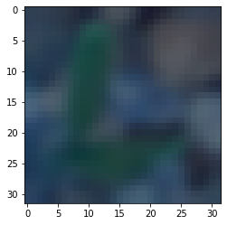

```
Test Image Index # 3
Actual Label #: 2
Actual Label Name: Cleavers
Predicted Label: 2
Predicted Label Name: Cleavers
```

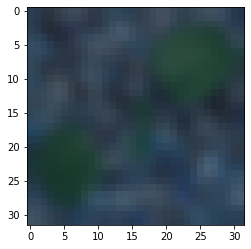

```
Test Image Index # 33
Actual Label #: 2
Actual Label Name: Cleavers
Predicted Label: 2
Predicted Label Name: Cleavers
```

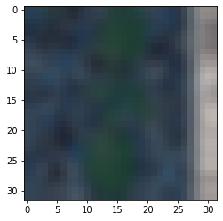

```
Test Image Index # 36
Actual Label #: 0
Actual Label Name: Black-grass
Predicted Label: 6
Predicted Label Name: Loose Silky-bent
```

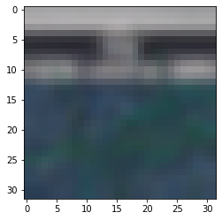

```
Test Image Index # 59
Actual Label #: 7
Actual Label Name: Maize
Predicted Label: 7
Predicted Label Name: Maize
```

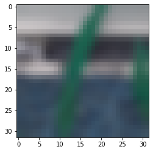

```python
indexes = np.array([2, 3, 33, 36, 59])
for i in indexes:
    print('Test Image Index #',i)
    image = X_test[i]
    actual_label = y_test_class[i]
    print('Actual Label #:',actual_label)
    print('Actual Label Name:',labels_dict[actual_label])
    pred_label = y_pred_class[i]
    print('Predicted Label:',pred_label)
    print('Predicted Label Name:',labels_dict[pred_label])
    plt.imshow(image)
    show()
```